# Assignment 5 - Hierarchical Clustering

Robert Andoh

2026-06-20

```r
library(cluster)
library(factoextra)
library(dplyr)
```

# Import Dataset

```r
cereals <- read.csv("Cereals.csv")

head(cereals)
```

```
##                        name mfr type calories protein fat sodium fiber carbo
## 1                 100%_Bran   N    C       70       4   1    130  10.0   5.0
## 2         100%_Natural_Bran   Q    C      120       3   5     15   2.0   8.0
## 3                  All-Bran   K    C       70       4   1    260   9.0   7.0
## 4 All-Bran_with_Extra_Fiber   K    C       50       4   0    140  14.0   8.0
## 5            Almond_Delight   R    C      110       2   2    200   1.0  14.0
## 6   Apple_Cinnamon_Cheerios   G    C      110       2   2    180   1.5  10.5
##   sugars potass vitamins shelf weight cups   rating
## 1      6    280       25     3      1 0.33 68.40297
## 2      8    135        0     3      1 1.00 33.98368
## 3      5    320       25     3      1 0.33 59.42551
## 4      0    330       25     3      1 0.50 93.70491
## 5      8     NA       25     3      1 0.75 34.38484
## 6     10     70       25     1      1 0.75 29.50954
```

```r
dim(cereals)
```

```
## [1] 77 16
```

```r
str(cereals)
```

```
## 'data.frame':    77 obs. of  16 variables:
##  $ name    : chr  "100%_Bran" "100%_Natural_Bran" "All-Bran" "All-Bran_with_Extra_Fiber" ...
##  $ mfr     : chr  "N" "Q" "K" "K" ...
##  $ type    : chr  "C" "C" "C" "C" ...
##  $ calories: int  70 120 70 50 110 110 110 130 90 90 ...
##  $ protein : int  4 3 4 4 2 2 2 3 2 3 ...
##  $ fat     : int  1 5 1 0 2 2 0 2 1 0 ...
##  $ sodium  : int  130 15 260 140 200 180 125 210 200 210 ...
##  $ fiber   : num  10 2 9 14 1 1.5 1 2 4 5 ...
##  $ carbo   : num  5 8 7 8 14 10.5 11 18 15 13 ...
##  $ sugars  : int  6 8 5 0 8 10 14 8 6 5 ...
##  $ potass  : int  280 135 320 330 NA 70 30 100 125 190 ...
##  $ vitamins: int  25 0 25 25 25 25 25 25 25 25 ...
##  $ shelf   : int  3 3 3 3 3 1 2 3 1 3 ...
##  $ weight  : num  1 1 1 1 1 1 1 1.33 1 1 ...
##  $ cups    : num  0.33 1 0.33 0.5 0.75 0.75 1 0.75 0.67 0.67 ...
##  $ rating  : num  68.4 34 59.4 93.7 34.4 ...
```

```r
names(cereals)
```

```
##  [1] "name"     "mfr"      "type"     "calories" "protein"  "fat"
##  [7] "sodium"   "fiber"    "carbo"    "sugars"   "potass"   "vitamins"
## [13] "shelf"    "weight"   "cups"     "rating"
```

# Check Missing Values

```r
colSums(is.na(cereals))
```

```
##     name      mfr     type calories  protein      fat   sodium    fiber
##        0        0        0        0        0        0        0        0
##    carbo   sugars   potass vitamins    shelf   weight     cups   rating
##        1        1        2        0        0        0        0        0
```

# Select Numerical Variables

```r
cereals_numeric <- cereals[, c(
  "calories",
  "protein",
  "fat",
  "sodium",
  "fiber",
  "carbo",
  "sugars",
  "potass",
  "vitamins",
  "shelf",
  "weight",
  "cups",
  "rating"
)]

head(cereals_numeric)
```

```
##   calories protein fat sodium fiber carbo sugars potass vitamins shelf weight
## 1       70       4   1    130  10.0   5.0      6    280       25     3      1
## 2      120       3   5     15   2.0   8.0      8    135        0     3      1
## 3       70       4   1    260   9.0   7.0      5    320       25     3      1
## 4       50       4   0    140  14.0   8.0      0    330       25     3      1
## 5      110       2   2    200   1.0  14.0      8     NA       25     3      1
## 6      110       2   2    180   1.5  10.5     10     70       25     1      1
##   cups   rating
## 1 0.33 68.40297
## 2 1.00 33.98368
## 3 0.33 59.42551
## 4 0.50 93.70491
## 5 0.75 34.38484
## 6 0.75 29.50954
```

```r
summary(cereals_numeric)
```

```
##     calories        protein           fat            sodium
##  Min.   : 50.0   Min.   :1.000   Min.   :0.000   Min.   :  0.0
##  1st Qu.:100.0   1st Qu.:2.000   1st Qu.:0.000   1st Qu.:130.0
##  Median :110.0   Median :3.000   Median :1.000   Median :180.0
##  Mean   :106.9   Mean   :2.545   Mean   :1.013   Mean   :159.7
##  3rd Qu.:110.0   3rd Qu.:3.000   3rd Qu.:2.000   3rd Qu.:210.0
##  Max.   :160.0   Max.   :6.000   Max.   :5.000   Max.   :320.0
##
##      fiber            carbo          sugars           potass
##  Min.   : 0.000   Min.   : 5.0   Min.   : 0.000   Min.   : 15.00
##  1st Qu.: 1.000   1st Qu.:12.0   1st Qu.: 3.000   1st Qu.: 42.50
##  Median : 2.000   Median :14.5   Median : 7.000   Median : 90.00
##  Mean   : 2.152   Mean   :14.8   Mean   : 7.026   Mean   : 98.67
##  3rd Qu.: 3.000   3rd Qu.:17.0   3rd Qu.:11.000   3rd Qu.:120.00
##  Max.   :14.000   Max.   :23.0   Max.   :15.000   Max.   :330.00
##                   NAs    :1      NAs    :1        NAs    :2
##     vitamins          shelf           weight          cups
##  Min.   :  0.00   Min.   :1.000   Min.   :0.50   Min.   :0.250
##  1st Qu.: 25.00   1st Qu.:1.000   1st Qu.:1.00   1st Qu.:0.670
##  Median : 25.00   Median :2.000   Median :1.00   Median :0.750
##  Mean   : 28.25   Mean   :2.208   Mean   :1.03   Mean   :0.821
##  3rd Qu.: 25.00   3rd Qu.:3.000   3rd Qu.:1.00   3rd Qu.:1.000
##  Max.   :100.00   Max.   :3.000   Max.   :1.50   Max.   :1.500
##
##      rating
##  Min.   :18.04
##  1st Qu.:33.17
##  Median :40.40
##  Mean   :42.67
##  3rd Qu.:50.83
##  Max.   :93.70
##
```

# Replace Missing Values

```r
cereals_numeric$carbo[is.na(cereals_numeric$carbo)] <-
  median(cereals_numeric$carbo, na.rm = TRUE)

cereals_numeric$sugars[is.na(cereals_numeric$sugars)] <-
  median(cereals_numeric$sugars, na.rm = TRUE)

cereals_numeric$potass[is.na(cereals_numeric$potass)] <-
  median(cereals_numeric$potass, na.rm = TRUE)

colSums(is.na(cereals_numeric))
```

```
## calories  protein      fat   sodium    fiber    carbo   sugars   potass
##        0        0        0        0        0        0        0        0
## vitamins    shelf   weight     cups   rating
##        0        0        0        0        0
```

# Standardize Variables

```r
cereals_scaled <- scale(cereals_numeric)

head(cereals_scaled)
```

```
##        calories    protein         fat     sodium       fiber      carbo
## [1,] -1.8929836  1.3286071 -0.01290349 -0.3539844  3.29284661 -2.5243405
## [2,]  0.6732089  0.4151897  3.96137277 -1.7257708 -0.06375361 -1.7514808
## [3,] -1.8929836  1.3286071 -0.01290349  1.1967306  2.87327158 -2.0091007
## [4,] -2.9194605  1.3286071 -1.00647256 -0.2346986  4.97114672 -1.7514808
## [5,]  0.1599704 -0.4982277  0.98066557  0.4810160 -0.48332864 -0.2057614
## [6,]  0.1599704 -0.4982277  0.98066557  0.2424445 -0.27354112 -1.1074310
##          sugars     potass   vitamins      shelf     weight       cups
## [1,] -0.2358694  2.6126578 -0.1453172  0.9515734 -0.1967771 -2.1100340
## [2,]  0.2239266  0.5260824 -1.2642598  0.9515734 -0.1967771  0.7690100
## [3,] -0.4657674  3.1882648 -0.1453172  0.9515734 -0.1967771 -2.1100340
## [4,] -1.6152574  3.3321665 -0.1453172  0.9515734 -0.1967771 -1.3795303
## [5,]  0.2239266 -0.1214755 -0.1453172  0.9515734 -0.1967771 -0.3052601
## [6,]  0.6837226 -0.4092790 -0.1453172 -1.4507595 -0.1967771 -0.3052601
##          rating
## [1,]  1.8321876
## [2,] -0.6180571
## [3,]  1.1930986
## [4,]  3.6333849
## [5,] -0.5894990
## [6,] -0.9365625
```

```r
summary(cereals_scaled)
```

```
##     calories          protein             fat              sodium
##  Min.   :-2.9195   Min.   :-1.4116   Min.   :-1.0065   Min.   :-1.9047
##  1st Qu.:-0.3533   1st Qu.:-0.4982   1st Qu.:-1.0065   1st Qu.:-0.3540
##  Median : 0.1600   Median : 0.4152   Median :-0.0129   Median : 0.2424
##  Mean   : 0.0000   Mean   : 0.0000   Mean   : 0.0000   Mean   : 0.0000
##  3rd Qu.: 0.1600   3rd Qu.: 0.4152   3rd Qu.: 0.9807   3rd Qu.: 0.6003
##  Max.   : 2.7262   Max.   : 3.1554   Max.   : 3.9614   Max.   : 1.9124
##      fiber              carbo              sugars              potass
##  Min.   :-0.90290   Min.   :-2.52434   Min.   :-1.615257   Min.   :-1.2007
##  1st Qu.:-0.48333   1st Qu.:-0.72100   1st Qu.:-0.925563   1st Qu.:-0.7690
##  Median :-0.06375   Median :-0.07695   Median :-0.005971   Median :-0.1215
##  Mean   : 0.00000   Mean   : 0.00000   Mean   : 0.000000   Mean   : 0.0000
##  3rd Qu.: 0.35582   3rd Qu.: 0.56710   3rd Qu.: 0.913621   3rd Qu.: 0.3102
##  Max.   : 4.97115   Max.   : 2.11282   Max.   : 1.833213   Max.   : 3.3322
##     vitamins           shelf             weight             cups
##  Min.   :-1.2643   Min.   :-1.4508   Min.   :-3.5195   Min.   :-2.4538
##  1st Qu.:-0.1453   1st Qu.:-1.4508   1st Qu.:-0.1968   1st Qu.:-0.6490
##  Median :-0.1453   Median :-0.2496   Median :-0.1968   Median :-0.3053
##  Mean   : 0.0000   Mean   : 0.0000   Mean   : 0.0000   Mean   : 0.0000
##  3rd Qu.:-0.1453   3rd Qu.: 0.9516   3rd Qu.:-0.1968   3rd Qu.: 0.7690
##  Max.   : 3.2115   Max.   : 0.9516   Max.   : 3.1260   Max.   : 2.9176
##      rating
##  Min.   :-1.7529
##  1st Qu.:-0.6757
##  Median :-0.1613
##  Mean   : 0.0000
##  3rd Qu.: 0.5811
##  Max.   : 3.6334
```

```r
dim(cereals_scaled)
```

[output not shown]

# Create Distance Matrix

```r
distance_matrix <- dist(
  cereals_scaled,
  method = "euclidean"
)

distance_matrix
```

[output not shown]

[output cut: 792 more lines]

[output not shown]

# Hierarchical Clustering

```r
hc_complete <- hclust(
  distance_matrix,
  method = "complete"
)

hc_complete
```

```
##
## Call:
## hclust(d = distance_matrix, method = "complete")
##
## Cluster method   : complete
## Distance         : euclidean
## Number of objects: 77
```

# Dendrogram

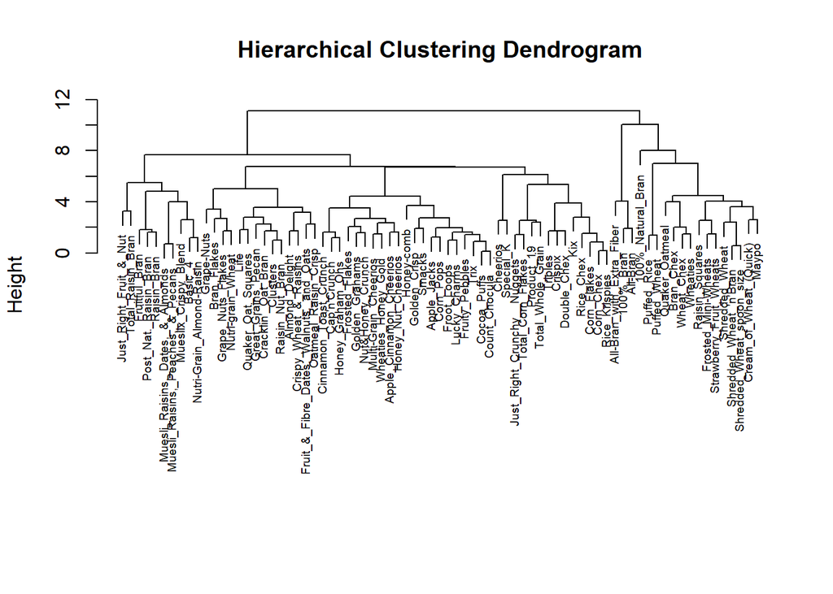

```r
plot(
  hc_complete,
  labels = cereals$name,
  main = "Hierarchical Clustering Dendrogram",
  xlab = "",
  sub = "",
  cex = 0.6
)
```

# Visualize Cluster Structure

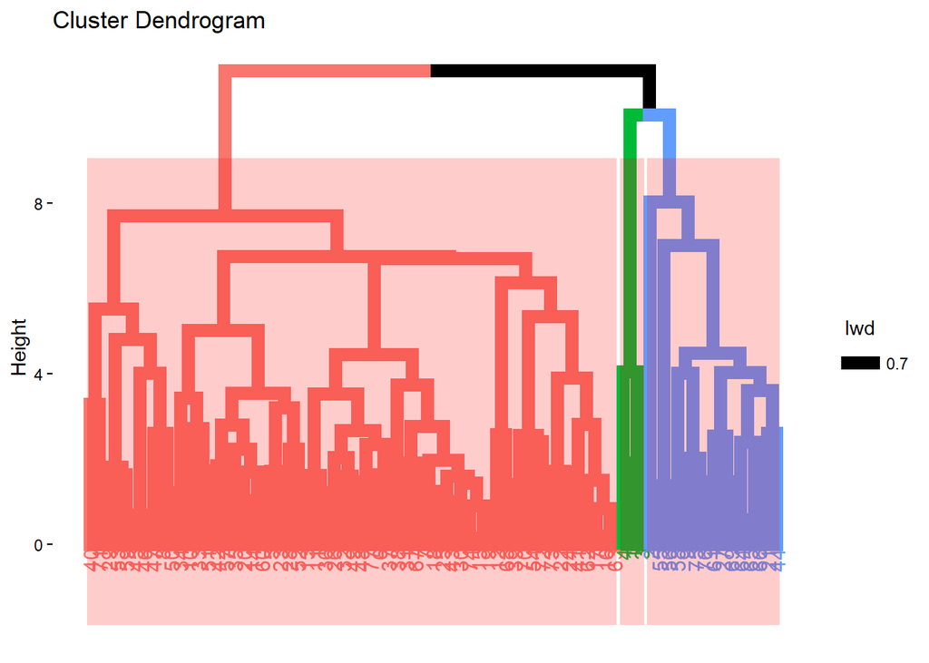

```r
fviz_dend(
  hc_complete,
  k = 3,
  rect = TRUE,
  rect_fill = TRUE,
  rect_border = "red"
)
```

# Assign Clusters

```r
cereals$Cluster <- as.factor(
  cutree(hc_complete, k = 3)
)

table(cereals$Cluster)
```

```
##
##  1  2  3
##  3 15 59
```

# Cluster Profiles

```r
cluster_summary <- aggregate(
  cereals_numeric,
  by = list(Cluster = cereals$Cluster),
  FUN = mean
)

cluster_summary
```

```
##   Cluster  calories  protein       fat    sodium     fiber     carbo   sugars
## 1       1  63.33333 4.000000 0.6666667 176.66667 11.000000  6.666667 3.666667
## 2       2  90.00000 2.733333 0.7333333  49.33333  2.313333 15.366667 3.200000
## 3       3 113.38983 2.423729 1.1016949 186.86441  1.661017 15.067797 8.169492
##      potass vitamins    shelf   weight      cups   rating
## 1 310.00000 25.00000 3.000000 1.000000 0.3866667 73.84446
## 2 100.00000 11.66667 1.800000 0.922000 0.8433333 57.80076
## 3  87.28814 32.62712 2.271186 1.058475 0.8374576 37.23245
```

# Additional Cluster Interpretation

```r
table(cereals$Cluster, cereals$mfr)
```

```
##
##      A  G  K  N  P  Q  R
##   1  0  0  2  1  0  0  0
##   2  1  1  2  5  0  4  2
##   3  0 21 19  0  9  4  6
```

```r
table(cereals$Cluster, cereals$type)
```

```
##
##      C  H
##   1  3  0
##   2 12  3
##   3 59  0
```

```r
table(cereals$Cluster, cereals$shelf)
```

```
##
##      1  2  3
##   1  0  0  3
##   2  7  4  4
##   3 13 17 29
```

# Interpretation Using Non-Clustering Variables

## Cereal Type

Cluster 1 contains only cold cereals. Cluster 2 contains both cold and hot cereals. Cluster 3 contains only cold cereals. Hot cereals appear concentrated within Cluster 2, suggesting they share similar nutritional characteristics.

# Shelf Placement

Cluster 1 cereals are found exclusively on Shelf 3. Cluster 2 cereals are distributed across all shelves. Cluster 3 cereals dominate Shelf 3 and represent the majority of products throughout the store.

This suggests that shelf placement may reflect product popularity and market positioning.

# Cluster Interpretation

## Cluster 1 (3 Cereals)

Cluster 1 contains only three cereals and represents the healthiest cereals in the dataset. These cereals have the lowest calorie content, the highest protein content, and exceptionally high fiber and potassium levels. Their relatively low sugar content suggests that these cereals are designed for health-conscious consumers seeking high nutritional value and dietary benefits.

# Cluster 2 (15 Cereals)

Cluster 2 represents moderately healthy cereals. These cereals have lower calories and sodium levels than Cluster 3 while maintaining moderate fiber and carbohydrate content. They also contain the lowest average sugar content among the clusters. This group appears to target consumers seeking a balance between taste and nutritional quality.

# Cluster 3 (59 Cereals)

Cluster 3 is the largest cluster and contains the majority of cereals in the dataset. These cereals have the highest calorie levels, highest sodium levels, and highest sugar content. Fiber and protein levels are relatively low compared to Cluster 1. This cluster likely represents mainstream commercial cereals designed primarily for taste and mass-market appeal rather than nutritional optimization.

# Findings

The hierarchical clustering analysis identified three distinct groups of cereals based on nutritional characteristics. Cluster 1 consisted of a small group of highly nutritious cereals characterized by high fiber, protein, and potassium content with low calories and sugars. Cluster 2 represented moderately healthy cereals with balanced nutritional profiles and the presence of both hot and cold cereal products. Cluster 3 contained the majority of cereals and was characterized by higher calories, sodium, and sugar levels, reflecting typical mass-market cereal products. The results demonstrate that hierarchical clustering can effectively segment cereal products into meaningful nutritional groups that may assist manufacturers, retailers, and consumers in product evaluation and decision-making.

# Conclusion

This assignment applied hierarchical clustering techniques to a cereal nutrition dataset consisting of 77 cereal products. After handling missing values and standardizing the numerical variables, Euclidean distance and complete linkage methods were used to construct a hierarchical clustering model.

The dendrogram and cluster analysis revealed three meaningful clusters that differed substantially in terms of calories, protein, fiber, sugar, sodium, and potassium content. Cluster 1 represented highly nutritious cereals, Cluster 2 represented moderately healthy cereals, and Cluster 3 represented mainstream cereal products with higher calorie and sugar levels.

Overall, the analysis demonstrates that hierarchical clustering is a valuable unsupervised machine learning technique for identifying natural groupings within complex datasets and providing actionable insights into product characteristics and consumer market segments